# PageRank

Freddy Drennan

July 17, 2016

This example is taken from *Linear Algebra and Its Applications* by David C. Lay.

# PageRank and the Google Matrix

The web can be modeled as a directed graph, with the dots representing webpages and the arrows representing links between the webpages. The way that we use matrices to describe these links follows below.

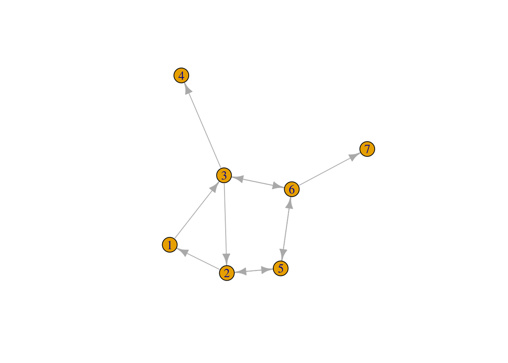

Bear with me, because I was unable to type column/row numbers with latex in R Markdown. It is an issue I will have to try and fix at a later time (if there is even a solution). The matrix $P$ is the *transition* matrix for the random walk on the directed graph as seen above. We can describe the columns as “from” and the rows as “to.” For example, look at the directed graph above and note the “$1$” link. There is only one place to go, and that is to 3. So, we will look at the first column (which stands for the “$1$” link) and see that there is a probability $1$ that the person will move to the link labeled $3$. The first column contains only a $1$. The $1$ is in the third row. So there is a $100\%$ chance of moving from link $1$ to link $3$.

Let’s now look at link $3$. We describe the transition from link $3$ with data in the third column of of matrix $P$. Looking down column $3$ we see that row $2$, $4$, and $6$ give equal probabilities of moving to either page $2$, $4$, or $6$. So, there is a $1/3$ chance that the person will decide to go to link $4$ from link $3$.

$$P =
\begin{bmatrix}
{0} & {1/2} & {0} & {0} & {0} & {0} & {0} \\
{0} & {0} & {1/3} & {0} & {1/2} & {0} & {0} \\
{1} & {0} & {0} & {0} & {0} & {1/3} & {0} \\
{0} & {0} & {1/3} & {1} & {0} & {0} & {0} \\
{0} & {1/2} & {0} & {0} & {0} & {1/3} & {0} \\
{0} & {0} & {1/3} & {0} & {1/2} & {0} & {0} \\
{0} & {0} & {0} & {0} & {0} & {1/3} & {1} \\
\end{bmatrix}$$

Also, notice that there aren’t any arrows coming from page $4$ or page $7$. If the user clicks on a link to these pages, there is no link to click on next. Therefore, the transition probabilities are set to equal 1 - the chain must stay on page $4$ or $7$ once it enters these states.

The code below shows how to calculate transitions in R using the matrixcalc package.

```r
library(matrixcalc)
```

```r
P <- matrix(c(0, 1/2, 0,   0, 0,   0,   0,
              0, 0,   1/3, 0, 1/2, 0,   0,
              1, 0,   0,   0, 0,   1/3, 0,
              0, 0,   1/3, 1, 0,   0,   0,
              0, 1/2, 0,   0, 0,   1/3, 0,
              0, 0,   1/3, 0, 1/2, 0,   0,
              0, 0,   0,   0, 0,   1/3, 1), nrow = 7, byrow=TRUE)
P
```

```
##      [,1] [,2]      [,3] [,4] [,5]      [,6] [,7]
## [1,]    0  0.5 0.0000000    0  0.0 0.0000000    0
## [2,]    0  0.0 0.3333333    0  0.5 0.0000000    0
## [3,]    1  0.0 0.0000000    0  0.0 0.3333333    0
## [4,]    0  0.0 0.3333333    1  0.0 0.0000000    0
## [5,]    0  0.5 0.0000000    0  0.0 0.3333333    0
## [6,]    0  0.0 0.3333333    0  0.5 0.0000000    0
## [7,]    0  0.0 0.0000000    0  0.0 0.3333333    1
```

```r
# This vector is this initial state for the user. There is a 1 in the 5th row, so the user is on page 5. We can take "powers" of the matrix and multiply the matrix P and vector x_0 in order to see the probability that the user will be on a given page after so many transitions.

x_0 <- matrix(c(0, 0, 0, 0, 1, 0, 0))
x_0
```

```
##      [,1]
## [1,]    0
## [2,]    0
## [3,]    0
## [4,]    0
## [5,]    1
## [6,]    0
## [7,]    0
```

$$x_0 =
\begin{bmatrix}
{0} \\
{0} \\
{0} \\
{0} \\
{1} \\
{0} \\
{0} \\
\end{bmatrix}$$

$$x_4 = P^4x_0 =
\begin{bmatrix}
{.1319} \\
{.0833} \\
{.0880} \\
{.1389} \\
{.2199} \\
{.0833} \\
{.2546} \\
\end{bmatrix}$$

```r
matrix.power(P, 4)%*%x_0
```

```
##            [,1]
## [1,] 0.13194444
## [2,] 0.08333333
## [3,] 0.08796296
## [4,] 0.13888889
## [5,] 0.21990741
## [6,] 0.08333333
## [7,] 0.25462963
```

So, the probability that the user is on page $1$ after 4 clicks when starting on page $5$ is $.1319$, page $2$ is $.0833$ and so on.

Remember pages $4$ and $7$ are absorbing states for the Markov chain. Technically, they are **dangling nodes** and can be used to represent data files on the internet where there are no links leaving from them.

The interesting thing about markov chains is their long term behavior, so let us look at where a user might be after 100 clicks.

```r
round(matrix.power(P, 100)%*%x_0, 3)
```

```
##       [,1]
## [1,] 0.000
## [2,] 0.000
## [3,] 0.000
## [4,] 0.455
## [5,] 0.000
## [6,] 0.000
## [7,] 0.545
```

Let’s fix the issue with the **dangling node** mentioned above. Instead of getting stuck on page $4$ and page $7$, let’s rewrite the $4$ and $7$ column to allow an equal chance of going back to any page (including itself). The surfer will pick any page on the web with equal probability and will move to that page. In terms os the transition patrix $P$, if state $j$ is an absorbing state, replace column $j$ of P with the vector:

$$\begin{bmatrix}
{1/n} \\
{1/n} \\
{1/n} \\
{\vdots} \\
{1/n} \\
\end{bmatrix}$$